# Bay Wheels Usage Patterns 2019

## by Amir Ragab

Bay Wheels(formerly known as Ford GoBike) is a regional public bicycle sharing system in the San Francisco Bay Area, California. Beginning operation in August 2013 as Bay Area Bike Share, the Ford GoBike system currently has over 2,600 bicycles in 262 stations across San Francisco, East Bay and San Jose. On June 28, 2017, the system officially launched as Ford GoBike in a partnership with Ford Motor Company.

Ford GoBike, like other bike share systems, consists of a fleet of specially designed, sturdy and durable bikes that are locked into a network of docking stations throughout the city. The bikes can be unlocked from one station and returned to any other station in the system, making them ideal for one-way trips. The bikes are available for use 24 hours/day, 7 days/week, 365 days/year and riders have access to all bikes in the network when they become a member or purchase a pass.

## Preliminary Wrangling

```python
#Import all packages and set plots to be embedded inline
import numpy as np
import pandas as pd
import matplotlib.pyplot as plt
import seaborn as sb
import os
import glob

%matplotlib inline
```

> Load in your dataset and describe its properties through the questions below. Try and motivate your exploration goals through this section.

```python
#Append all of the 2019 months' data into a single dataset
folder_name = 'Data'
months = [pd.read_csv(f) for f in glob.glob(os.path.join(folder_name, '*.csv'))]
year = pd.concat(months, ignore_index=True)
print(year.shape)
year.sample(5)
```

```
(2506983, 15)
```

|  | duration_sec | start_time | end_time | start_station_id | start_station_name | start_station_latitude | start_station_longitude | end_station_id | end_station_name | end_station_latitude | end_station_longitude | bike_id | user_type | bike_share_for_all_trip | rental_access_method |
| --- | --- | --- | --- | --- | --- | --- | --- | --- | --- | --- | --- | --- | --- | --- | --- |
| 2085735 | 821 | 2019-10-11 14:10:37.4570 | 2019-10-11 14:24:18.5530 | 13.0 | Commercial St at Montgomery St | 37.794231 | -122.402923 | 419.0 | Fern St at Polk St | 37.788197 | -122.420373 | 798 | Subscriber | No | NaN |
| 23748 | 343 | 2019-01-29 14:03:54.0760 | 2019-01-29 14:09:37.5570 | 345.0 | Hubbell St at 16th St | 37.766474 | -122.398295 | 125.0 | 20th St at Bryant St | 37.759200 | -122.409851 | 5202 | Subscriber | No | NaN |
| 1435809 | 984 | 2019-07-30 17:27:35 | 2019-07-30 17:44:00 | NaN | NaN | 37.762536 | -122.398369 | NaN | NaN | 37.790516 | -122.396048 | 533739 | Subscriber | NaN | app |
| 701390 | 293 | 2019-04-19 17:29:04.5280 | 2019-04-19 17:33:58.0880 | 49.0 | S Park St at 3rd St | 37.780760 | -122.394989 | 19.0 | Post St at Kearny St | 37.788975 | -122.403452 | 425 | Customer | No | NaN |
| 1911135 | 737 | 2019-09-04 16:21:35.4120 | 2019-09-04 16:33:52.9800 | 13.0 | Commercial St at Montgomery St | 37.794231 | -122.402923 | 67.0 | San Francisco Caltrain Station 2 (Townsend St... | 37.776639 | -122.395526 | 9657 | Subscriber | No | NaN |

```python
#Convert the dataset into csv format
year.to_csv('bay_wheels_2019.csv', index=False)
```

```python
year = pd.read_csv('bay_wheels_2019.csv')
year.head()
```

|  | duration_sec | start_time | end_time | start_station_id | start_station_name | start_station_latitude | start_station_longitude | end_station_id | end_station_name | end_station_latitude | end_station_longitude | bike_id | user_type | bike_share_for_all_trip | rental_access_method |
| --- | --- | --- | --- | --- | --- | --- | --- | --- | --- | --- | --- | --- | --- | --- | --- |
| 0 | 80825 | 2019-01-31 17:57:44.6130 | 2019-02-01 16:24:49.8640 | 229.0 | Foothill Blvd at 42nd Ave | 37.775745 | -122.213037 | 196.0 | Grand Ave at Perkins St | 37.808894 | -122.256460 | 4861 | Subscriber | No | NaN |
| 1 | 65900 | 2019-01-31 20:58:33.8860 | 2019-02-01 15:16:54.1730 | 4.0 | Cyril Magnin St at Ellis St | 37.785881 | -122.408915 | 134.0 | Valencia St at 24th St | 37.752428 | -122.420628 | 5506 | Subscriber | No | NaN |
| 2 | 62633 | 2019-01-31 18:06:52.9240 | 2019-02-01 11:30:46.5300 | 245.0 | Downtown Berkeley BART | 37.870139 | -122.268422 | 157.0 | 65th St at Hollis St | 37.846784 | -122.291376 | 2717 | Customer | No | NaN |
| 3 | 44680 | 2019-01-31 19:46:09.7190 | 2019-02-01 08:10:50.3180 | 85.0 | Church St at Duboce Ave | 37.770083 | -122.429156 | 53.0 | Grove St at Divisadero | 37.775946 | -122.437777 | 4557 | Customer | No | NaN |
| 4 | 60709 | 2019-01-31 14:19:01.5410 | 2019-02-01 07:10:51.0650 | 16.0 | Steuart St at Market St | 37.794130 | -122.394430 | 28.0 | The Embarcadero at Bryant St | 37.787168 | -122.388098 | 2100 | Customer | No | NaN |

```python
year.info()
```

```
<class 'pandas.core.frame.DataFrame'>
RangeIndex: 2506983 entries, 0 to 2506982
Data columns (total 15 columns):
 #   Column                   Dtype
---  ------                   -----
 0   duration_sec             int64
 1   start_time               object
 2   end_time                 object
 3   start_station_id         float64
 4   start_station_name       object
 5   start_station_latitude   float64
 6   start_station_longitude  float64
 7   end_station_id           float64
 8   end_station_name         object
 9   end_station_latitude     float64
 10  end_station_longitude    float64
 11  bike_id                  int64
 12  user_type                object
 13  bike_share_for_all_trip  object
 14  rental_access_method     object
dtypes: float64(6), int64(2), object(7)
memory usage: 286.9+ MB
```

```python
year.isnull().sum()
```

```
duration_sec                     0
start_time                       0
end_time                         0
start_station_id             80734
start_station_name           80133
start_station_latitude           0
start_station_longitude          0
end_station_id               82902
end_station_name             82350
end_station_latitude             0
end_station_longitude            0
bike_id                          0
user_type                        0
bike_share_for_all_trip     243259
rental_access_method       2386145
dtype: int64
```

```python
year.user_type.value_counts()
```

```
Subscriber    2021166
Customer       485817
Name: user_type, dtype: int64
```

```python
year.bike_share_for_all_trip.value_counts()
```

```
No     2086152
Yes     177572
Name: bike_share_for_all_trip, dtype: int64
```

```python
year.duplicated().sum()
```

```
0
```

**We have some null values and we have to fix some data types, so we should clean our data.**

```python
#Let's first fix the data types
df = year.copy()
df['start_time'] = pd.to_datetime(df['start_time'])
df['end_time'] = pd.to_datetime(df['end_time'])

df['start_station_id'] = df['start_station_id'].astype('str')
df['end_station_id'] = df['end_station_id'].astype('str')

df['bike_id'] = df['bike_id'].astype('str')
df['user_type'] = df['user_type'].astype('category')

df.info(null_counts=True)
```

```
<class 'pandas.core.frame.DataFrame'>
RangeIndex: 2506983 entries, 0 to 2506982
Data columns (total 15 columns):
 #   Column                   Non-Null Count    Dtype
---  ------                   --------------    -----
 0   duration_sec             2506983 non-null  int64
 1   start_time               2506983 non-null  datetime64[ns]
 2   end_time                 2506983 non-null  datetime64[ns]
 3   start_station_id         2506983 non-null  object
 4   start_station_name       2426850 non-null  object
 5   start_station_latitude   2506983 non-null  float64
 6   start_station_longitude  2506983 non-null  float64
 7   end_station_id           2506983 non-null  object
 8   end_station_name         2424633 non-null  object
 9   end_station_latitude     2506983 non-null  float64
 10  end_station_longitude    2506983 non-null  float64
 11  bike_id                  2506983 non-null  object
 12  user_type                2506983 non-null  category
 13  bike_share_for_all_trip  2263724 non-null  object
 14  rental_access_method     120838 non-null   object
dtypes: category(1), datetime64[ns](2), float64(4), int64(1), object(7)
memory usage: 270.2+ MB
```

```python
#As most of the rental_access_method column contains null values, let's drop the column
df.drop('rental_access_method', axis=1, inplace = True)
df.info()
```

```
<class 'pandas.core.frame.DataFrame'>
RangeIndex: 2506983 entries, 0 to 2506982
Data columns (total 14 columns):
 #   Column                   Dtype
---  ------                   -----
 0   duration_sec             int64
 1   start_time               datetime64[ns]
 2   end_time                 datetime64[ns]
 3   start_station_id         object
 4   start_station_name       object
 5   start_station_latitude   float64
 6   start_station_longitude  float64
 7   end_station_id           object
 8   end_station_name         object
 9   end_station_latitude     float64
 10  end_station_longitude    float64
 11  bike_id                  object
 12  user_type                category
 13  bike_share_for_all_trip  object
dtypes: category(1), datetime64[ns](2), float64(4), int64(1), object(6)
memory usage: 251.0+ MB
```

```python
#Let's drop the null values
df.dropna(axis =0, inplace = True)
df.isnull().sum()
```

```
duration_sec               0
start_time                 0
end_time                   0
start_station_id           0
start_station_name         0
start_station_latitude     0
start_station_longitude    0
end_station_id             0
end_station_name           0
end_station_latitude       0
end_station_longitude      0
bike_id                    0
user_type                  0
bike_share_for_all_trip    0
dtype: int64
```

```python
df.info(null_counts=True)
```

```
<class 'pandas.core.frame.DataFrame'>
Int64Index: 2262979 entries, 0 to 2355470
Data columns (total 14 columns):
 #   Column                   Non-Null Count    Dtype
---  ------                   --------------    -----
 0   duration_sec             2262979 non-null  int64
 1   start_time               2262979 non-null  datetime64[ns]
 2   end_time                 2262979 non-null  datetime64[ns]
 3   start_station_id         2262979 non-null  object
 4   start_station_name       2262979 non-null  object
 5   start_station_latitude   2262979 non-null  float64
 6   start_station_longitude  2262979 non-null  float64
 7   end_station_id           2262979 non-null  object
 8   end_station_name         2262979 non-null  object
 9   end_station_latitude     2262979 non-null  float64
 10  end_station_longitude    2262979 non-null  float64
 11  bike_id                  2262979 non-null  object
 12  user_type                2262979 non-null  category
 13  bike_share_for_all_trip  2262979 non-null  object
dtypes: category(1), datetime64[ns](2), float64(4), int64(1), object(6)
memory usage: 243.9+ MB
```

let's make new columns: duration in minutes, start date in yyyy-mm-dd format, start hour of the day, day of week, and month. for the format codes, check out this link: https://docs.python.org/3/library/datetime.html#strftime-and-strptime-behavior

```python
#let's add some new columns
df['duration_minute'] = df['duration_sec']/60
df['start_date'] = df.start_time.dt.strftime('%Y-%m-%d')

df['start_hour'] = df.start_time.dt.strftime('%H')
df['start_dayofweek'] = df.start_time.dt.strftime('%A')

df['start_month'] = df.start_time.dt.strftime('%B')

df.head()
```

|  | duration_sec | start_time | end_time | start_station_id | start_station_name | start_station_latitude | start_station_longitude | end_station_id | end_station_name | end_station_latitude | end_station_longitude | bike_id | user_type | bike_share_for_all_trip | duration_minute | start_date | start_hour | start_dayofweek | start_month |
| --- | --- | --- | --- | --- | --- | --- | --- | --- | --- | --- | --- | --- | --- | --- | --- | --- | --- | --- | --- |
| 0 | 80825 | 2019-01-31 17:57:44.613 | 2019-02-01 16:24:49.864 | 229.0 | Foothill Blvd at 42nd Ave | 37.775745 | -122.213037 | 196.0 | Grand Ave at Perkins St | 37.808894 | -122.256460 | 4861 | Subscriber | No | 1347.083333 | 2019-01-31 | 17 | Thursday | January |
| 1 | 65900 | 2019-01-31 20:58:33.886 | 2019-02-01 15:16:54.173 | 4.0 | Cyril Magnin St at Ellis St | 37.785881 | -122.408915 | 134.0 | Valencia St at 24th St | 37.752428 | -122.420628 | 5506 | Subscriber | No | 1098.333333 | 2019-01-31 | 20 | Thursday | January |
| 2 | 62633 | 2019-01-31 18:06:52.924 | 2019-02-01 11:30:46.530 | 245.0 | Downtown Berkeley BART | 37.870139 | -122.268422 | 157.0 | 65th St at Hollis St | 37.846784 | -122.291376 | 2717 | Customer | No | 1043.883333 | 2019-01-31 | 18 | Thursday | January |
| 3 | 44680 | 2019-01-31 19:46:09.719 | 2019-02-01 08:10:50.318 | 85.0 | Church St at Duboce Ave | 37.770083 | -122.429156 | 53.0 | Grove St at Divisadero | 37.775946 | -122.437777 | 4557 | Customer | No | 744.666667 | 2019-01-31 | 19 | Thursday | January |
| 4 | 60709 | 2019-01-31 14:19:01.541 | 2019-02-01 07:10:51.065 | 16.0 | Steuart St at Market St | 37.794130 | -122.394430 | 28.0 | The Embarcadero at Bryant St | 37.787168 | -122.388098 | 2100 | Customer | No | 1011.816667 | 2019-01-31 | 14 | Thursday | January |

```python
df.info()
```

```
<class 'pandas.core.frame.DataFrame'>
Int64Index: 2262979 entries, 0 to 2355470
Data columns (total 19 columns):
 #   Column                   Dtype
---  ------                   -----
 0   duration_sec             int64
 1   start_time               datetime64[ns]
 2   end_time                 datetime64[ns]
 3   start_station_id         object
 4   start_station_name       object
 5   start_station_latitude   float64
 6   start_station_longitude  float64
 7   end_station_id           object
 8   end_station_name         object
 9   end_station_latitude     float64
 10  end_station_longitude    float64
 11  bike_id                  object
 12  user_type                category
 13  bike_share_for_all_trip  object
 14  duration_minute          float64
 15  start_date               object
 16  start_hour               object
 17  start_dayofweek          object
 18  start_month              object
dtypes: category(1), datetime64[ns](2), float64(5), int64(1), object(10)
memory usage: 330.2+ MB
```

### What is the structure of your dataset?

The final dataset contains the combined data of each of the 12 months. It contains more than 2,200,000 individual records and 19 variables.

> The variables include the start and end of the trip, the start and end stations ids and names, the user type, and the stations' latitudes and longititude.

### What is/are the main feature(s) of interest in your dataset?

> I am mostly interested in exploring the times in the year bikes are used the most, along with the user type that uses them the most, along with the duration of the trips.

### What features in the dataset do you think will help support your investigation into your feature(s) of interest?

> The most helpful features would be the trips' start date/time, the month, and the duration will help with understanding how long a trip usually takes and when does it begin and end.

## Univariate Exploration

**Let's first look at the distribution of the duration_minutes variable.

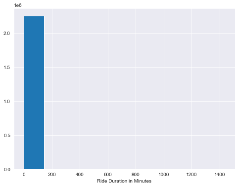

```python
plt.rcParams['figure.figsize'] = 8, 6
base_color = sb.color_palette('colorblind')[0]
sb.set_style('darkgrid')

plt.hist(data=df, x='duration_minute');
plt.xlabel('Ride Duration in Minutes');
```

The distribution spans alot to the right, so there must be some outliers skewing the distribution. Most of the points are in the 0 to 160 range, so, let's zoom in to these points

```python
df['duration_minute'].describe(percentiles=[.99])
```

```
count    2.262979e+06
mean     1.344884e+01
std      3.203676e+01
min      1.016667e+00
50%      9.483333e+00
99%      6.883333e+01
max      1.436950e+03
Name: duration_minute, dtype: float64
```

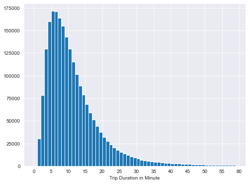

```python
bins = np.arange(0, 60, 1)
ticks = np.arange(0, 61, 5)
plt.hist(data=df, x='duration_minute', bins=bins);
plt.xticks(ticks, ticks);
plt.xlabel('Trip Duration in Minute');
```

As expected, most of the data falls between 5 and 15 minutes. let's next filter the data.

```python
df = df.query('duration_minute <= 60')
df.info(null_counts=True)
```

```
<class 'pandas.core.frame.DataFrame'>
Int64Index: 2235694 entries, 6 to 2355470
Data columns (total 19 columns):
 #   Column                   Non-Null Count    Dtype
---  ------                   --------------    -----
 0   duration_sec             2235694 non-null  int64
 1   start_time               2235694 non-null  datetime64[ns]
 2   end_time                 2235694 non-null  datetime64[ns]
 3   start_station_id         2235694 non-null  object
 4   start_station_name       2235694 non-null  object
 5   start_station_latitude   2235694 non-null  float64
 6   start_station_longitude  2235694 non-null  float64
 7   end_station_id           2235694 non-null  object
 8   end_station_name         2235694 non-null  object
 9   end_station_latitude     2235694 non-null  float64
 10  end_station_longitude    2235694 non-null  float64
 11  bike_id                  2235694 non-null  object
 12  user_type                2235694 non-null  category
 13  bike_share_for_all_trip  2235694 non-null  object
 14  duration_minute          2235694 non-null  float64
 15  start_date               2235694 non-null  object
 16  start_hour               2235694 non-null  object
 17  start_dayofweek          2235694 non-null  object
 18  start_month              2235694 non-null  object
dtypes: category(1), datetime64[ns](2), float64(5), int64(1), object(10)
memory usage: 326.2+ MB
```

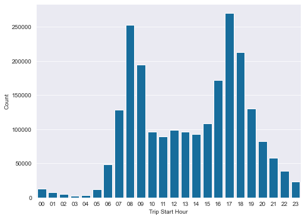

```python
#Ride start hour distribution
sb.countplot(data=df, x='start_hour', color=base_color);
plt.xlabel('Trip Start Hour');
plt.ylabel('Count');
```

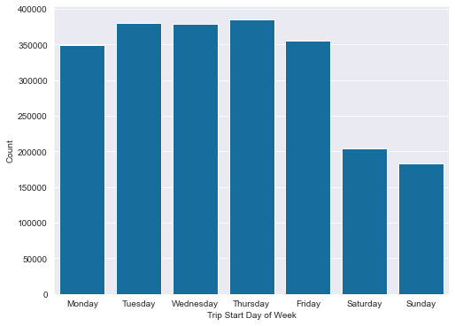

```python
#Order the weekdays
days = ['Monday', 'Tuesday', 'Wednesday', 'Thursday', 'Friday', 'Saturday', 'Sunday']
daycat = pd.api.types.CategoricalDtype(ordered=True, categories=days)
df['start_dayofweek'] = df['start_dayofweek'].astype(daycat)
#Weekday distribution
sb.countplot(data=df, x='start_dayofweek', color=base_color);
plt.xlabel('Trip Start Day of Week');
plt.ylabel('Count');
```

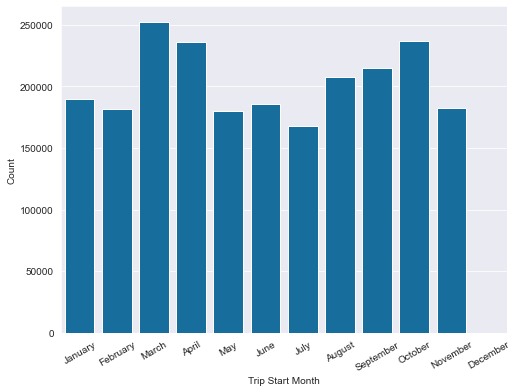

```python
#Order the months
months = ['January', 'February', 'March', 'April', 'May', 'June', 'July', 'August', 'September', 'October', 'November', 'December']
categories = pd.api.types.CategoricalDtype(ordered=True, categories=months)
df['start_month'] = df['start_month'].astype(categories)
#Months distribution
sb.countplot(data=df, x='start_month', color=base_color);
plt.xticks(rotation=30);
plt.xlabel('Trip Start Month');
plt.ylabel('Count');
```

Most of the rides seemed to start in weekdays, with rides starting early in the morning and before sunset. The bikes were probably used for commuting to and from work. With the most popular months being early in the spring and the late summer and in the fall. With december having no data, probably having to do with the coronavirus.

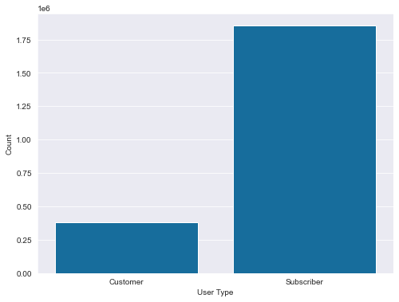

```python
#User type difference
sb.countplot(data=df, x='user_type', color=base_color);
plt.xlabel('User Type');
plt.ylabel('Count');
```

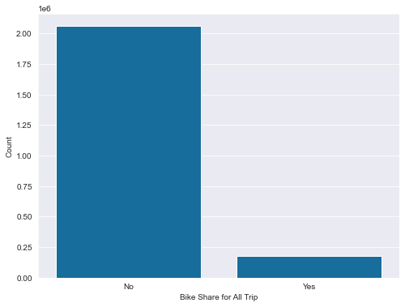

```python
sb.countplot(data=df, x='bike_share_for_all_trip', color=base_color);
plt.xlabel('Bike Share for All Trip');
plt.ylabel('Count');
```

### Discuss the distribution(s) of your variable(s) of interest. Were there any unusual points? Did you need to perform any transformations?

> The number of rides peaked around early morning and before sunset, with bikes being used more during weekdays compared to weekends. The most popular seasons were early spring, late summer, and fall, probably due to the weather. There were some outliers in the ride duration variable, but most rides were between 5 and 15 minutes. The data was rather straightforward, so no transformations were needed.

### Of the features you investigated, were there any unusual distributions? Did you perform any operations on the data to tidy, adjust, or change the form of the data? If so, why did you do this?

> The original data contained some strange outliers, but we zoomed in to where most of the data fell in and filtered out the outliers.

## Bivariate Exploration

```python
#We should export the filtered data into a csv file
df.to_csv('Bay_Wheels_clean.csv', index=False)
```

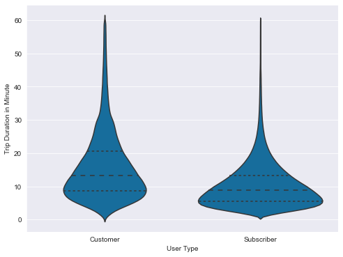

```python
#Trip duration compared to user types
sb.violinplot(data=df, x='user_type', y='duration_minute', color=base_color, inner='quartile');
plt.xlabel('User Type');
plt.ylabel('Trip Duration in Minute');
```

It seems like most subscribers rent bikes for a shorter period, and more customers tend to rent them for longer periods.

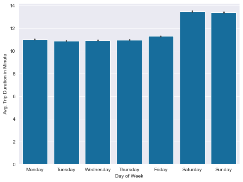

```python
#Average ride duration on different days of the week
sb.barplot(data=df, x='start_dayofweek', y='duration_minute', color=base_color);
plt.xlabel('Day of Week');
plt.ylabel('Avg. Trip Duration in Minute');
```

Rides tend to be shorter on weekdays compared to weekends, probably because bikes are used more in commute in weekdays, unlike weekends.

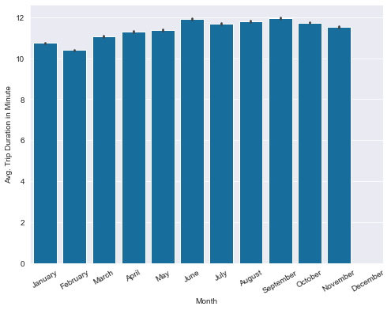

```python
#Average ride durations in each month
sb.barplot(data=df, x='start_month', y='duration_minute', color=base_color);
plt.xticks(rotation=30);
plt.xlabel('Month');
plt.ylabel('Avg. Trip Duration in Minute');
```

The ride duration tend to increase in march, reaching the peak in june and september.

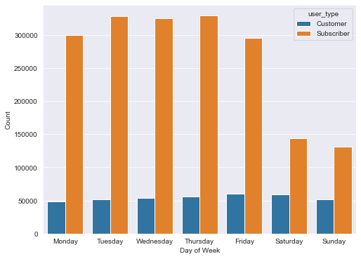

```python
#Differences in customers and subscribers
sb.countplot(data=df, x='start_dayofweek', hue='user_type');
plt.xlabel('Day of Week');
plt.ylabel('Count');
```

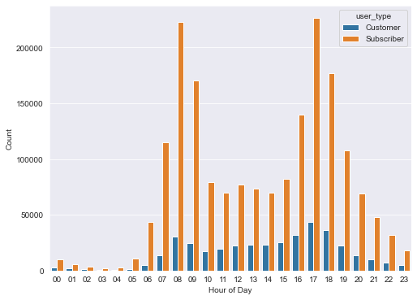

```python
sb.countplot(data=df, x='start_hour', hue='user_type');
plt.xlabel('Hour of Day');
plt.ylabel('Count');
```

As we expected, usage peaks at the start and end of work, with subscribers being the majority. Customer doesn't have this strong correlation with rush hours as they likely use them for other purposes like leisurely rides.

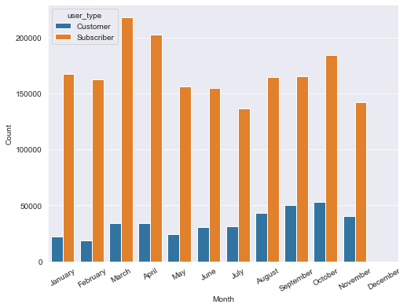

```python
sb.countplot(data=df, x='start_month', hue='user_type');
plt.xticks(rotation=30);
plt.xlabel('Month');
plt.ylabel('Count');
```

As we expected once again, riders ride the most during early spring, late summer, and early fall.

### Talk about some of the relationships you observed in this part of the investigation. How did the feature(s) of interest vary with other features in the dataset?

> Subscribers are the majority of riders. Subscribers and customers have completely different usage habits: subscribers seem to use bikes for commuting during rush hours, while customers likely use them for more leisurely activities

### Did you observe any interesting relationships between the other features (not the main feature(s) of interest)?

> Subscribers tend to use bikes for a shorter duration than customers, and usage peaks around march and april.

## Multivariate Exploration

**How does the ride duration vary throughout the week?**

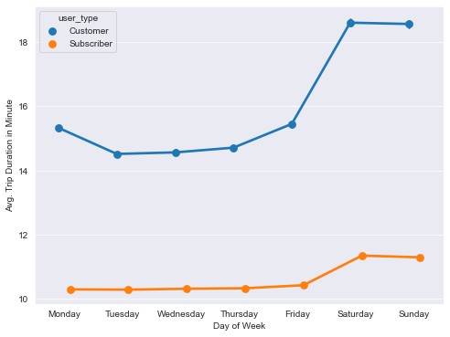

```python
sb.pointplot(data=df, x='start_dayofweek', y='duration_minute', hue='user_type', dodge=0.2);
plt.xlabel('Day of Week');
plt.ylabel('Avg. Trip Duration in Minute');
```

Subscribers tend to use bikes for a shorter duration than customers, with their duration increasing on weekends. Customers, however, tend to use them for a longer time, with their duration also increasing on weekends.

```python
#Necessary transformation to convert to heatmap #1
customer = df.query('user_type == "Customer"')
c_count = customer.groupby(['start_dayofweek', 'start_hour']).size()
c_count = c_count.reset_index(name='count')
c_count = c_count.pivot(index='start_dayofweek', columns='start_hour', values='count')
c_count
```

| start_hour start_dayofweek | 00 | 01 | 02 | 03 | 04 | 05 | 06 | 07 | 08 | 09 | ... | 14 | 15 | 16 | 17 | 18 | 19 | 20 | 21 | 22 | 23 |
| --- | --- | --- | --- | --- | --- | --- | --- | --- | --- | --- | --- | --- | --- | --- | --- | --- | --- | --- | --- | --- | --- |
| Monday | 241 | 110 | 64 | 54 | 60 | 210 | 840 | 2376 | 5219 | 3616 | ... | 2356 | 2713 | 3917 | 6378 | 5161 | 3033 | 1741 | 1176 | 808 | 370 |
| Tuesday | 223 | 125 | 70 | 52 | 53 | 206 | 956 | 2758 | 5761 | 3894 | ... | 2042 | 2531 | 3780 | 7108 | 5834 | 3507 | 2022 | 1482 | 973 | 489 |
| Wednesday | 227 | 111 | 65 | 45 | 47 | 257 | 1033 | 2649 | 5770 | 3969 | ... | 2210 | 2902 | 4235 | 7141 | 6000 | 3386 | 2097 | 1528 | 1093 | 622 |
| Thursday | 254 | 136 | 75 | 79 | 61 | 247 | 946 | 2539 | 5746 | 4127 | ... | 2345 | 2877 | 4219 | 7101 | 6075 | 3610 | 2236 | 1680 | 1245 | 713 |
| Friday | 375 | 194 | 125 | 82 | 66 | 214 | 789 | 2258 | 5378 | 4424 | ... | 3142 | 3681 | 5280 | 7153 | 5839 | 3556 | 2099 | 1634 | 1437 | 1035 |
| Saturday | 737 | 545 | 301 | 117 | 82 | 72 | 192 | 473 | 1210 | 2262 | ... | 5932 | 5673 | 5554 | 4766 | 3978 | 2867 | 1916 | 1416 | 1205 | 910 |
| Sunday | 706 | 505 | 351 | 135 | 91 | 103 | 172 | 448 | 1050 | 2000 | ... | 5438 | 5336 | 5040 | 4079 | 3173 | 2243 | 1368 | 1005 | 595 | 454 |

7 rows × 24 columns

```python
#Necessary transformation to convert to heatmap #1
subscriber = df.query('user_type == "Subscriber"')
s_count = subscriber.groupby(['start_dayofweek', 'start_hour']).size()
s_count = s_count.reset_index(name='count')
s_count = s_count.pivot(index='start_dayofweek', columns='start_hour', values='count')
s_count
```

| start_hour start_dayofweek | 00 | 01 | 02 | 03 | 04 | 05 | 06 | 07 | 08 | 09 | ... | 14 | 15 | 16 | 17 | 18 | 19 | 20 | 21 | 22 | 23 |
| --- | --- | --- | --- | --- | --- | --- | --- | --- | --- | --- | --- | --- | --- | --- | --- | --- | --- | --- | --- | --- | --- |
| Monday | 871 | 448 | 336 | 205 | 388 | 1820 | 8021 | 21182 | 41622 | 29345 | ... | 8509 | 10885 | 21888 | 40927 | 31837 | 18486 | 11091 | 6967 | 4142 | 2048 |
| Tuesday | 950 | 551 | 354 | 175 | 409 | 2168 | 9298 | 24429 | 45760 | 32896 | ... | 9212 | 11564 | 23563 | 43512 | 34127 | 19821 | 12401 | 8151 | 4830 | 2319 |
| Wednesday | 994 | 514 | 311 | 171 | 373 | 2045 | 8600 | 22544 | 43998 | 31399 | ... | 9424 | 12364 | 24121 | 42782 | 33437 | 19962 | 12261 | 8598 | 5274 | 2647 |
| Thursday | 1234 | 574 | 391 | 194 | 413 | 1963 | 8549 | 23152 | 44107 | 32372 | ... | 9938 | 12371 | 23702 | 41898 | 32895 | 19720 | 12786 | 9071 | 5683 | 3142 |
| Friday | 1504 | 778 | 450 | 257 | 419 | 1755 | 7039 | 19501 | 39037 | 29816 | ... | 10459 | 13672 | 24537 | 35965 | 25868 | 14736 | 8855 | 6493 | 5181 | 3562 |
| Saturday | 2369 | 1430 | 891 | 336 | 248 | 425 | 1018 | 2335 | 5008 | 8017 | ... | 11304 | 11051 | 10802 | 10804 | 9520 | 7797 | 5815 | 4682 | 3713 | 2889 |
| Sunday | 1855 | 1268 | 860 | 358 | 196 | 359 | 723 | 1745 | 3475 | 6256 | ... | 10837 | 10692 | 11031 | 10570 | 9320 | 7255 | 5658 | 4131 | 2848 | 1774 |

7 rows × 24 columns

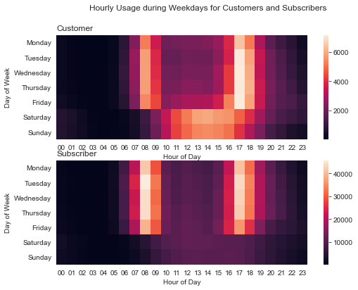

```python
#Plot the heatmap
plt.suptitle('Hourly Usage during Weekdays for Customers and Subscribers')
plt.subplot(2, 1, 1)
sb.heatmap(c_count);
plt.title('Customer', loc='left');
plt.xlabel('Hour of Day');
plt.ylabel('Day of Week');

plt.subplot(2, 1, 2)
sb.heatmap(s_count);
plt.title('Subscriber', loc='left');
plt.xlabel('Hour of Day');
plt.ylabel('Day of Week');
```

As we can see, subscriber usage is more focused on the rush hours on weekdays, while customer usage is more prominent on weekends and on later hours throughout the week.

### Were there any interesting or surprising interactions between features?

> There wasn't any strange interactions as the data is quite coherent and realistic. All the different features only complemented each other.